# Chaper 1

This [book](https://web.stanford.edu/~hastie/CASI/data.html) was referenced by an rblogger post. Downloaded as a Kindle file.

Attempting to follow the statistical principles with R-Code. Data used in this book is available online [here](https://web.stanford.edu/~hastie/CASI/data.html).

### Chapter 1

#### Figure 1.1

Kitney fitness `tot` vs `age`

References: 1. Use of `pander` library pander 2. Latex commands * single vs double $ sign

### Setup

```r
library(readr)
library(magrittr)
library(tidyr)
library(data.table)
topdir = "C:/Users/yashroff/Dropbox/share/Projects/CASI"
setwd(topdir)
```

Download the data

```r
kidney_url <- "https://web.stanford.edu/~hastie/CASI_files/DATA/kidney.txt"
kidney <- read_delim(kidney_url,
    " ", escape_double = FALSE, trim_ws = TRUE)
# View(kidney)
```

Alt: Download Data

```r
kidney <- read.table(kidney_url, header=TRUE, sep=" ")
```

$$y = \hat{\beta}_0 + \hat{\beta}_1x$$
$$\sum\limits_{i=1}^n (y_i - \beta_0 - \beta_1x_i)^2$$

```r
lm.fit <- lm(tot ~ age, data=kidney)
beta0 <- lm.fit$coefficients[1]
beta1 <- lm.fit$coefficients[2]
#print(lm.fit)
cat("Intercept:", beta0, "\nSlope:", beta1)
```

```
Intercept: 2.860027
Slope: -0.07858842
```

```r
ages <- data.frame(age = seq(20, 80, 10))
y = predict(lm.fit, ages, se.fit = TRUE)
print(data.frame(ages$age, y))
```

|  | ages.age | fit | se.fit | df | residual.scale |
| --- | --- | --- | --- | --- | --- |
| 1 | 20 | 1.2882585 | 0.2066481 | 155 | 1.801024 |
| 2 | 30 | 0.5023743 | 0.1549648 | 155 | 1.801024 |
| 3 | 40 | -0.2835098 | 0.1473983 | 155 | 1.801024 |
| 4 | 50 | -1.0693940 | 0.1893143 | 155 | 1.801024 |
| 5 | 60 | -1.8552781 | 0.2575947 | 155 | 1.801024 |
| 6 | 70 | -2.6411623 | 0.3365586 | 155 | 1.801024 |
| 7 | 80 | -3.4270465 | 0.4202260 | 155 | 1.801024 |

### Example of using loess

```r
cars.lo <- loess(dist ~ speed, cars)
predict(cars.lo, data.frame(speed = seq(5, 30, 1)), se = TRUE)
```

```
$fit
        1         2         3         4         5         6         7         8         9        10        11        12
 7.797353 10.002308 12.499786 15.281082 18.446568 21.865315 25.517015 29.350386 33.230660 37.167935 41.205226 45.055736
       13        14        15        16        17        18        19        20        21        22        23        24
48.355889 49.824812 51.986702 56.461318 61.959729 68.569313 76.316068 85.212121 95.324047        NA        NA        NA
       25        26
       NA        NA

$se.fit
       1        2        3        4        5        6        7        8        9       10       11       12       13
7.568120 5.945831 4.990827 4.545284 4.308639 4.115049 3.789542 3.716231 3.776947 4.091747 4.709568 4.245427 4.035929
      14       15       16       17       18       19       20       21       22       23       24       25       26
3.753410 4.004705 4.043190 4.026105 4.074664 4.570818 5.954217 8.302014       NA       NA       NA       NA       NA

$residual.scale
[1] 15.29496

$df
[1] 44.6179
```

```r
# to get extrapolation
cars.lo2 <- loess(dist ~ speed, cars,
  control = loess.control(surface = "direct"))
predict(cars.lo2, data.frame(speed = seq(5, 30, 1)), se = TRUE)
```

```
$fit
         1          2          3          4          5          6          7          8          9         10         11
  7.741006   9.926596  12.442424  15.281082  18.425712  21.865315  25.713413  29.350386  33.230660  37.167935  41.205226
        12         13         14         15         16         17         18         19         20         21         22
 45.781544  48.355889  50.067148  51.986702  56.445263  62.025404  68.569313  76.193111  85.053364  95.300523 106.974661
        23         24         25         26
120.092581 134.665851 150.698545 168.190283

$se.fit
        1         2         3         4         5         6         7         8         9        10        11        12
 7.565991  5.959097  5.012013  4.550013  4.321596  4.119331  3.939804  3.720098  3.780877  4.096004  4.714469  4.398936
       13        14        15        16        17        18        19        20        21        22        23        24
 4.040129  4.184257  4.008873  4.061865  4.033998  4.078904  4.584606  5.952480  8.306901 11.601911 15.792480 20.864660
       25        26
26.823827 33.683999

$residual.scale
[1] 15.31087

$df
[1] 44.55085
```

```r
plot(kidney, main="lowess(kidney)")
lines(lowess(kidney), col=2)
```

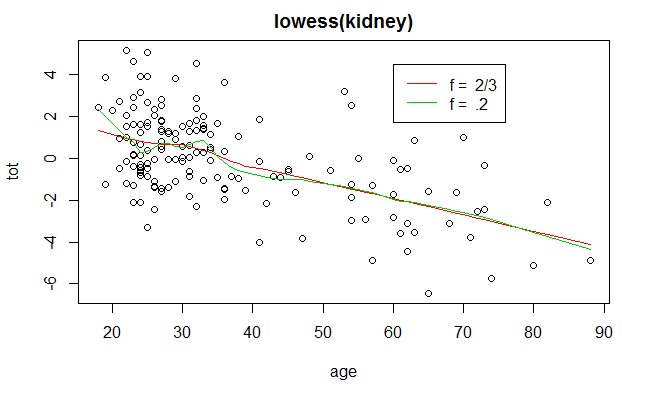

```r
lines(lowess(kidney, f=.2), col=3)
legend(60, 4.5, c(paste("f = ", c("2/3", ".2"))), lty = 1, col = 2:3)
```

### Bootstrap

The boot command executes the resampling of your dataset and calculation of your statistic(s) of interest on these samples. Before calling boot, you need to define a function that will return the statistic(s) that you would like to bootstrap. The first argument passed to the function should be your dataset. The second argument can be an index vector of the observations in your dataset to use or a frequency or weight vector that informs the sampling probabilities. The example below uses the default index vector and assumes we wish to use all of our observations. The statistic of interest here is the correlation coefficient of write and math [ref](http://www.ats.ucla.edu/stat/r/faq/boot.htm).

```r
# Example:
library(boot)
hsb2<-read.table("http://www.ats.ucla.edu/stat/data/hsb2.csv", sep=",", header=T)
f <- function(d, i){
    d2 <- d[i,]
    return(cor(d2$write, d2$math))
}
bootcorr <- boot(hsb2, f, R=500)
bootcorr
```

```
ORDINARY NONPARAMETRIC BOOTSTRAP


Call:
boot(data = hsb2, statistic = f, R = 500)


Bootstrap Statistics :
     original        bias    std. error
t1* 0.6174493 -0.0006039915  0.03948165
```

```r
summary(bootcorr)
```

```
          Length Class      Mode
t0          1    -none-     numeric
t         500    -none-     numeric
R           1    -none-     numeric
data       11    data.frame list
seed      626    -none-     numeric
statistic   1    -none-     function
sim         1    -none-     character
call        4    -none-     call
stype       1    -none-     character
strata    200    -none-     numeric
weights   200    -none-     numeric
```

Now, back to our data:

```r
get.beta=function(data,indices){
  data=data[indices,] #let boot to select sample
  #lm.out=lm(tot ~ age,data=data)
  #return(lm.out$coefficients)
  return(cor(data$age, data$tot))
}
bootcorr=boot(kidney,get.beta,R=1000) #generate 1000 random samples
summary(bootcorr)
```

```
          Length Class      Mode
t0           1   -none-     numeric
t         1000   -none-     numeric
R            1   -none-     numeric
data         2   data.frame list
seed       626   -none-     numeric
statistic    1   -none-     function
sim          1   -none-     character
call         4   -none-     call
stype        1   -none-     character
strata     157   -none-     numeric
weights    157   -none-     numeric
```

Knowing the seed value would allow us to replicate this analysis, if needed, and from the t vector and t0, we could calculate the bias and standard error:

```r
mean(bootcorr$t)-bootcorr$t0
```

```
[1] -6.749066e-05
```

```r
sd(bootcorr$t)
```

```
[1] 0.0557011
```

### Bootstrap confidence intervals and plots

To look at a histogram and normal quantile-quantile plot of your bootstrap estimates, you can use plot with the “boot” object you created. The histogram includes a dotted vertical line indicating the location of the original statistic.

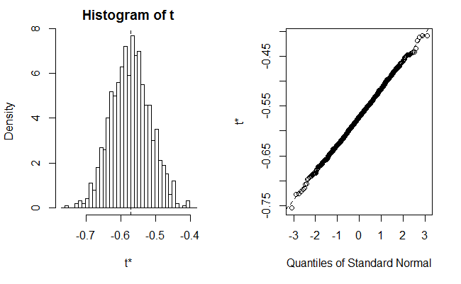

```r
plot(bootcorr)
```

# 1.2 Hypothesis testing

Leukemia data

Gene expression measurements on 72 leukemia patients, 47 “ALL” (see section 1.2), 25 “AML”. These data arise from the landmark Golub et al (1999) Science paper.

There is a larger set consisting of 7128 genes, which was used in Chapters 1, 10, 11, and possibly elsewhere. It is stored as the 7128 x 72 matrix (10MB) leukemia_big.csv, with the column names denoting the class labels.

The histograms in Figure 1.4 arise from row 136 of this matrix, and the histogram in Figure 1.5 is of the 7128 two-sample t-test statistics on the rows (genes). The data can be read directly into R via the command leukemia_big <- read.csv(“http://web.stanford.edu/~hastie/CASI_files/DATA/leukemia_big.csv”)

There is also a smaller subset of these data, consisting of 3571 genes, used in Section 19.1. It is stored as the 3571 x 72 matrix (5MB) leukemia_small.csv, with again the column names denoting the class labels. The data can be read directly into R via the command leukemia_small <- read.csv(“http://web.stanford.edu/~hastie/CASI_files/DATA/leukemia_small.csv”)

Disclaimer: these data come with a data analysis challenge. The columns of the two datasets are in different order. Furthermore, the genes in the big dataset have been transformed, with the exact transformation used lost in time. We also do not know the correspondence between the 3157 and 7128 genes. The first person to solve this puzzle completely will be thanked and their name will appear forever on this page.

```r
leukemia_big <- read.csv("http://web.stanford.edu/~hastie/CASI_files/DATA/leukemia_big.csv")
```

Some analysis of the data:

```r
gene136AML <- leukemia_big[136,AMLindx] %>% unlist %>% unname
gene136ALL <- leukemia_big[136,ALLindx] %>% unlist %>% unname
```

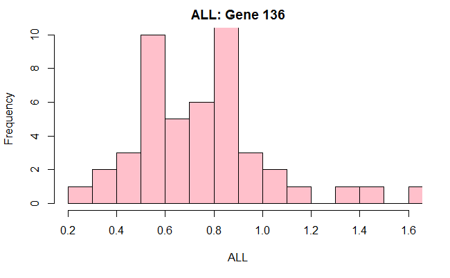

```r
gene136 <- list(unname(unlist(leukemia_big[136,ALLindx])), unname(unlist(leukemia_big[136,AMLindx])))
hist(gene136[[1]], col = 'pink', xlim = c(0.2,1.6), breaks = 11, xlab = "ALL", main = "ALL: Gene 136", ylim = c(0,10))
```

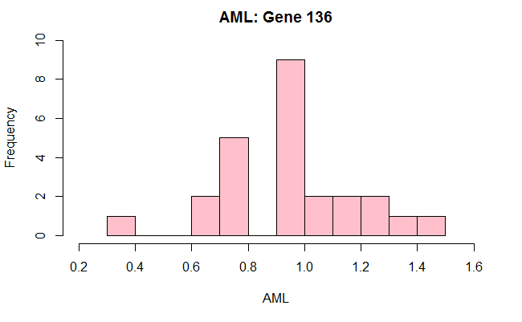

```r
hist(gene136[[2]], col = 'pink', xlim = c(0.2,1.6), breaks = 11, xlab = "AML", main = "AML: Gene 136", ylim = c(0,10))
```

The `AML` group shows more activity in gene 136. $\overline{ALL} = 0.7524794$ and $\overline{AML} = 0.9499731$

Calculate your own t.test [ref](http://stats.stackexchange.com/questions/30394/how-to-perform-two-sample-t-tests-in-r-by-inputting-sample-statistics-rather-tha)

```r
# m1, m2: the sample means
# s1, s2: the sample standard deviations
# n1, n2: the same sizes
# m0: the null value for the difference in means to be tested for. Default is 0.
# equal.variance: whether or not to assume equal variance. Default is FALSE.
t.test2 <- function(m1,m2,s1,s2,n1,n2,m0=0,equal.variance=FALSE)
{
    if( equal.variance==FALSE )
    {
        se <- sqrt( (s1^2/n1) + (s2^2/n2) )
        # welch-satterthwaite df
        df <- ( (s1^2/n1 + s2^2/n2)^2 )/( (s1^2/n1)^2/(n1-1) + (s2^2/n2)^2/(n2-1) )
    } else
    {
        # pooled standard deviation, scaled by the sample sizes
        se <- sqrt( (1/n1 + 1/n2) * ((n1-1)*s1^2 + (n2-1)*s2^2)/(n1+n2-2) )
        df <- n1+n2-2
    }
    t <- (m1-m2-m0)/se
    dat <- c(m1-m2, se, t, 2*pt(-abs(t),df))
    names(dat) <- c("Difference of means", "Std Error", "t", "p-value")
    return(dat)
}
x1 = rnorm(100)
x2 = rnorm(200)
# you'll find this output agrees with that of t.test when you input x1,x2
t.test2( mean(x1), mean(x2), sd(x1), sd(x2), 100, 200)
```

```
Difference of means           Std Error                   t             p-value
          0.1174304           0.1217458           0.9645546           0.3360371
```

```r
t.test(x = x1, y = x2, var.equal = FALSE)
```

```
    Welch Two Sample t-test

data:  x1 and x2
t = 0.96455, df = 183.54, p-value = 0.336
alternative hypothesis: true difference in means is not equal to 0
95 percent confidence interval:
 -0.1227707  0.3576316
sample estimates:
  mean of x   mean of y
 0.09989509 -0.01753536
```

### Equal or unequal sample sizes, equal variance

This test is used only when it can be assumed that the two distributions have the same variance. The t statistic to test whether the means are different can be calculated as follows:

$$t = \frac{\overline{X}_1 - \overline{X}_2}{s_p~~\dot~~\sqrt{\frac{1}{n_1} + \frac{1}{n_2}}}$$
where,
$$s_p = \sqrt{\frac{(n_1-1)s_{X_1}^2 + (n_2-1)s_{X_2}^2}{n_1+n_2-2}}$$

```r
x1 = gene136[[1]]
x2 = gene136[[2]]
x1bar = mean(x1)
x2bar = mean(x2)
sdx1 = sd(x1)
sdx2 = sd(x2)
n1 = length(gene136[[1]])
n2 = length(gene136[[2]])
sp = sqrt(((n1-1)*sdx1^2 + (n2-1)*sdx2^2)/(n1+n2-2))
se = (sp*sqrt(1/n1 + 1/n2))
t = (x1bar - x2bar)/se
df = n1+n2-2
pval = 2*pt(-abs(t), df)
dat <- c((x1bar-x2bar), se, t, pval)
names(dat) <- c("Difference of means", "Std Error", "t", "p-value")
print(dat, 4)
```

```
Difference of means           Std Error                   t             p-value
          -0.197494            0.065525           -3.014003            0.003589
```

```r
cat("\nFor comparison")
```

```
For comparison
```

```r
t.test(x = x1, y = x2, var.equal = TRUE)
```

```
    Two Sample t-test

data:  x1 and x2
t = -3.014, df = 70, p-value = 0.003589
alternative hypothesis: true difference in means is not equal to 0
95 percent confidence interval:
 -0.32817995 -0.06680742
sample estimates:
mean of x mean of y
0.7524794 0.9499731
```

#### t-test for all genes

```r
get_t <- function(dat=leukemia_big) {
  n = nrow(dat)
  AMLindx <- grep("AML",names(dat))
  ALLindx <- grep("ALL",names(dat))
  genes = seq_len(nrow(dat))
  t_list = numeric(nrow(dat))
  for (gene in genes) {
    x1 <- dat[gene, ALLindx] %>% unlist %>% unname
    x2 <- dat[gene, AMLindx] %>% unlist %>% unname
    t_list[gene] <- t.test(x = x1, y = x2, var.equal = TRUE)$statistic
  }
  return (t_list)
}
t_list <- get_t(leukemia_big)
```

Reviewing the results

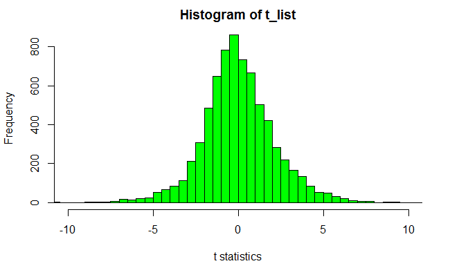

```r
hist(t_list, col = 'green', xlim = c(-10,10), breaks = 75, xlab = "t statistics", ylab = "Frequency")
```